# Data_Visualization_Slide slides

## Project: Data Visualization on fordgobike_tripdata

### Introduction

Ford GoBike is a regional public bicycle sharing system in the San Francisco Bay Area, California. Beginning operation in August 2013 as Bay Area Bike Share, the Ford GoBike system currently has over 2,600 bicycles in 262 stations across San Francisco, East Bay and San Jose. On June 28, 2017, the system officially launched as Ford GoBike in a partnership with Ford Motor Company.

Ford GoBike, like other bike share systems, consists of a fleet of specially designed, sturdy and durable bikes that are locked into a network of docking stations throughout the city. The bikes can be unlocked from one station and returned to any other station in the system, making them ideal for one-way trips. The bikes are available for use 24 hours/day, 7 days/week, 365 days/year and riders have access to all bikes in the network when they become a member or purchase a pass. I have taken the data from [this link](https://s3.amazonaws.com/fordgobike-data/2017-fordgobike-tripdata.csv).

### Data Wrangling

### What is the structure of dataset?

The dataset has origanially 519700 bike rides that happen in 2017 in the San Francisco Bay Area. The dataset contained features about:

- trip duration: how long the trip took in seconds
- start time/end time: start/end date/time for the bike rides.
- stations: start/end station, name, geolocation (latitude/longitude)
- anonymized customer data: gender, birth date and user type
- rented bikes: bike id

The dataset was further enhanced with features that I may find neccessary to perform interesting analysis:

- rental time: hour of the day, weekday, month & year
- customer: age
- member_age_groups

### What is/are the main feature(s) of interest in your dataset?

I'm most interested in figuring out when and where bikes are high in demand (during the day/weekday/month). Moreover which age range and gender uses the service the most and if the service is mostly used by members or casual riders.

### What features in the dataset do you think will help support your investigation into your feature(s) of interest?

I expect that the start time will be most exploited in my analysis as well as customer related data. I expect that location and datetime will have the strongest effect on bike demand.

## Univariate Exploration

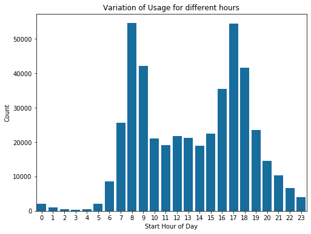

```python
# trip distribution over day hours

plt.rcParams['figure.figsize'] = 8, 6
base_color = sb.color_palette('colorblind')[0]

sb.countplot(data=df_clean, x='start_time_hour', color=base_color);
plt.xlabel('Start Hour of Day');
plt.ylabel('Count');
plt.title('Variation of Usage for different hours');
```

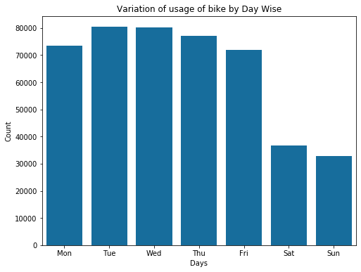

```python
# trip distribution over week

plt.rcParams['figure.figsize'] = 8, 6
base_color = sb.color_palette('colorblind')[0]

sb.countplot(data=df_clean, x='start_time_weekday', color=base_color);
plt.xlabel('Days');
plt.ylabel('Count');
plt.title('Variation of usage of bike by Day Wise');
```

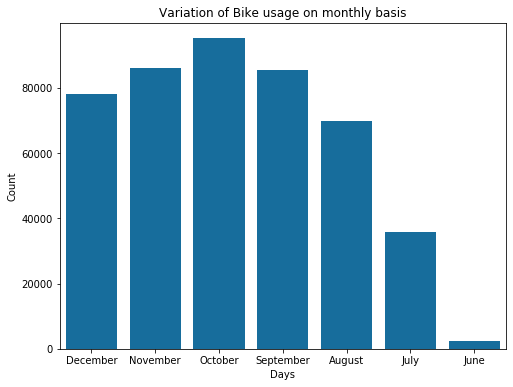

```python
# trip distribution over month

plt.rcParams['figure.figsize'] = 8, 6
base_color = sb.color_palette('colorblind')[0]

sb.countplot(data=df_clean, x='start_time_month_name', color=base_color);
plt.xlabel('Days');
plt.ylabel('Count');
plt.title('Variation of Bike usage on monthly basis');
```

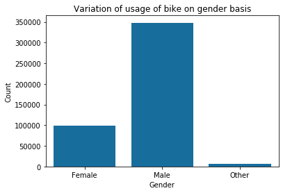

```python
# distribution of trips over gender

plt.rcParams['figure.figsize'] = 6, 4
base_color = sb.color_palette('colorblind')[0]

sb.countplot(data=df_clean, x='member_gender', color=base_color);
plt.xlabel('Gender');
plt.ylabel('Count');
plt.title('Variation of usage of bike on gender basis');
```

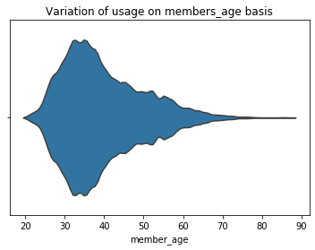

```python
# trip distribution over member_age

sb.violinplot(data=df_clean,x='member_age',inner=None);
plt.title('Variation of usage on members_age basis');
```

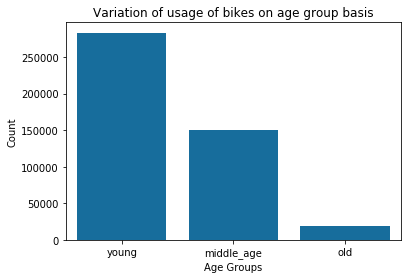

```python
# trip distribution over member_age_group
plt.rcParams['figure.figsize'] = 6, 4
base_color = sb.color_palette('colorblind')[0]

sb.countplot(data=df_clean, x='member_age_groups', color=base_color);
plt.xlabel('Age Groups');
plt.ylabel('Count');
plt.title('Variation of usage of bikes on age group basis');
```

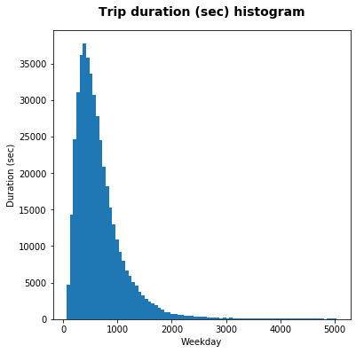

```python
# code for the (histogram) duration (sec) distribution per user type

bin_edges = np.arange(61, 5000+60,60)

plt.hist(data = df_clean, x = 'duration_sec', bins = bin_edges)

plt.title("Trip duration (sec) histogram", y=1.03, fontsize=14, fontweight='semibold')
plt.xlabel('Weekday')
plt.ylabel('Duration (sec)');
```

## Bivariate Exploration

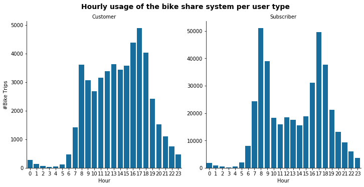

```python
#
# hourly usege of the bike sharing system per user type

g = sb.catplot(data=df_clean, x='start_time_hour', col="user_type", kind='count', sharey = False,
            color = base_color)
g.set_axis_labels("Hour", "#Bike Trips")
g.set_titles("{col_name}")
g.fig.suptitle('Hourly usage of the bike share system per user type', y=1.03, fontsize=14, fontweight='semibold');
```

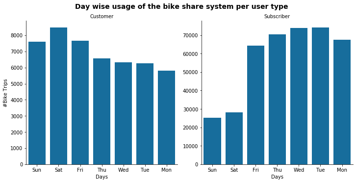

```python
# hourly usege of the bike sharing system per user type

g = sb.catplot(data=df_clean, x='start_time_weekday', col="user_type", kind='count', sharey = False,
            color = base_color)
g.set_axis_labels("Days", "#Bike Trips")
g.set_titles("{col_name}")
g.fig.suptitle('Day wise usage of the bike share system per user type', y=1.03, fontsize=14, fontweight='semibold');
```

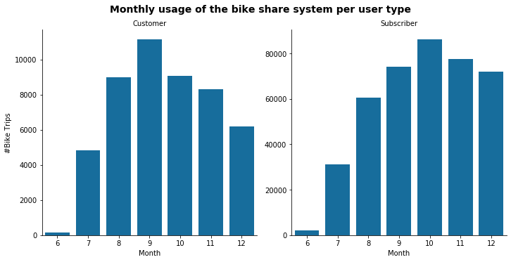

```python
# monthly usege of the bike sharing system per user type
g = sb.catplot(data=df_clean, x='start_time_month', col="user_type", kind='count', sharey = False,
            color = base_color)
g.set_axis_labels("Month", "#Bike Trips")
g.set_titles("{col_name}")
g.fig.suptitle('Monthly usage of the bike share system per user type', y=1.03, fontsize=14, fontweight='semibold');
```

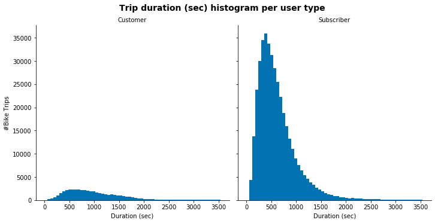

```python
# code for the (histogram) duration (sec) distribution per user type

g = sb.FacetGrid(df_clean, col="user_type", margin_titles=True, size=5)
bin_edges = np.arange(0, 3600,60)
g.map(plt.hist, "duration_sec", color=base_color, bins=bin_edges)
g.set_axis_labels("Duration (sec)", "#Bike Trips")
g.set_titles(col_template = '{col_name}')
g.fig.suptitle('Trip duration (sec) histogram per user type', y=1.03, fontsize=14, fontweight='semibold');
```

## Multivariate Exploration

In this section I will further explore the dataset by adding gender to the customer type and check the hourly distribution of bike rides during weekdays for customers and subscribers.

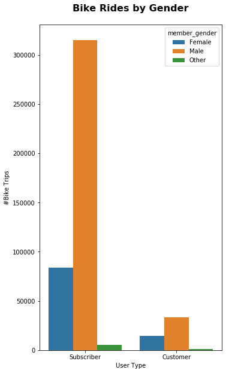

```python
plt.figure(figsize = [12, 10])

# code for the bar chart
plt.subplot(1, 2, 1)

g = sb.countplot(data=df_clean, x="user_type", hue="member_gender", order=df_clean.user_type.value_counts().index)
g.set_xlabel('User Type')
g.set_ylabel('#Bike Trips')
g.set_title('Bike Rides by Gender', y=1.03, fontsize=16, fontweight='semibold');
```

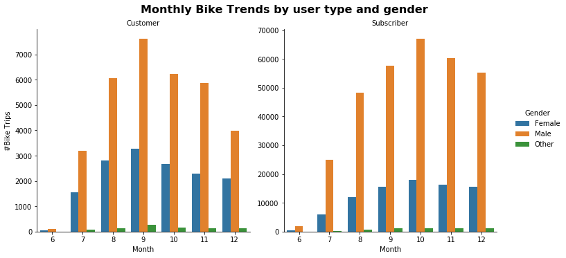

```python
g = sb.catplot(data=df_clean, x='start_time_month', col="user_type", hue="member_gender", kind='count', sharey = False)
g.set_axis_labels("Month", "#Bike Trips")
g._legend.set_title('Gender')
g.set_titles("{col_name}")
g.fig.suptitle('Monthly Bike Trends by user type and gender', y=1.03, fontsize=16, fontweight='semibold');
```

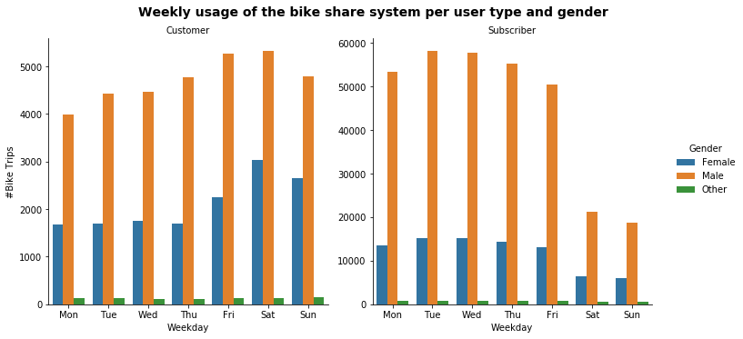

```python
# weekday usege of the bike sharing system per user type and gender
weekday = ['Mon', 'Tue', 'Wed', 'Thu', 'Fri', 'Sat', 'Sun']
g = sb.catplot(data=df_clean, x='start_time_weekday', col="user_type", hue='member_gender', kind='count', sharey = False,
                order = weekday)
g.set_axis_labels("Weekday", "#Bike Trips")
g._legend.set_title('Gender')
g.set_titles("{col_name}")
g.fig.suptitle('Weekly usage of the bike share system per user type and gender', y=1.03, fontsize=14, fontweight='semibold');
```

As in the previous section, the trend is very similar for males and females: customers use the system more often during weekends than within a week (although the jump in bike used on weekends is much higher for females than for males); subscribers use the system mainly within a week.

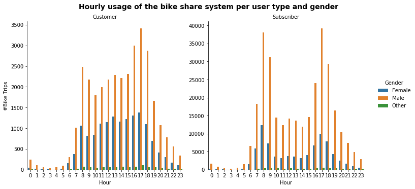

```python
# hourly usege of the bike sharing system per user type and gender
g = sb.catplot(data=df_clean, x='start_time_hour', col="user_type", hue='member_gender', kind='count', sharey = False)
g.set_axis_labels("Hour", "#Bike Trips")
g._legend.set_title('Gender')
g.set_titles("{col_name}")
g.fig.suptitle('Hourly usage of the bike share system per user type and gender', y=1.03, fontsize=14, fontweight='semibold');
```

During the day, both males and females use the system the same way: customers use bikes mainly between 8 am - 7 pm; subscribers on the other side use the system at around 8-9am and 5-6pm when they go and come back from work.

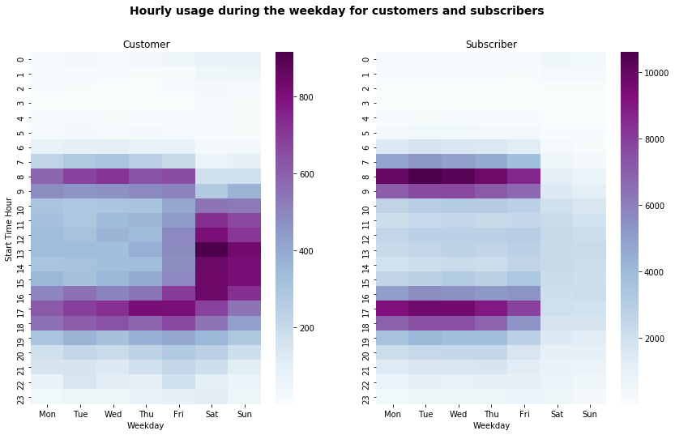

```python
# Setting the weekday order
df_clean['start_time_weekday'] = pd.Categorical(df_clean['start_time_weekday'],
                                                categories=['Mon','Tue','Wed','Thu','Fri','Sat', 'Sun'],
                                                ordered=True)
plt.figure(figsize=(14,8))
plt.suptitle('Hourly usage during the weekday for customers and subscribers', fontsize=14, fontweight='semibold')

# heatmap for customers
plt.subplot(1, 2, 1)
df_customer = df_clean.query('user_type == "Customer"').groupby(["start_time_hour", "start_time_weekday"])["bike_id"].size().reset_index()
df_customer = df_customer.pivot("start_time_hour", "start_time_weekday", "bike_id")
sb.heatmap(df_customer, cmap="BuPu")

plt.title("Customer", y=1.015)
plt.xlabel('Weekday')
plt.ylabel('Start Time Hour')

# heatmap for subscribers
plt.subplot(1, 2, 2)
df_subscriber = df_clean.query('user_type == "Subscriber"').groupby(["start_time_hour", "start_time_weekday"])["bike_id"].size().reset_index()
df_subscriber = df_subscriber.pivot("start_time_hour", "start_time_weekday", "bike_id")
sb.heatmap(df_subscriber, cmap="BuPu")

plt.title("Subscriber", y=1.015)
plt.xlabel('Weekday')
plt.ylabel('');
```

The plot perfectly summarizes in one place the diffrent trends for customers and subscribers I was writing up before.

#### Customers use the bike sharing system more often on weekends:

- weekdays: most bike rides hapen around 8-9am and 5-6pm with the peak on Fridays around 5pm
- weekends: most bike rides happen between 10am - 8pm with the peak on Saturdays around 2pm

#### Subscribers use the bike sharing system mainly on weekdays:

- weekdays: most bike rides hapen around 8-9am and 5-6pm with the peak on Tuesdays around 8am
- weekends: bikes are still rented but there is a significant drop in numbers of rented bikes throughout the entire weekends